# Analyzing Sneakers Price From Stockx

# Sixiao He - DATS 6103

## Background

With the Thanksgiving day and Christmas day coming, many people will buy some sneakers as presents for their friends and family, it is necessary to know the fluctuation of the price which influenced by several factors.This project is to help you to get your favorite shoes with suitable price.

## Description from Stockx:

Description from StockX: The data consists of a random sample of all Off-White x Nike and Yeezy 350 sales from between 9/1/2017 and 2/13/2019. There are 99,956 total sales in the data set; 27,794 Off-White sales, and 72,162 Yeezy sales. And the data only consists of U.S. sales only.

## 1. Data Cleaning

```python
import pandas as pd
import numpy as np
import seaborn as sns
import matplotlib.pyplot as plt
import matplotlib.ticker as plticker
import chart_studio.plotly as py
%matplotlib inline
jupyter nbconvert my_notebook.ipynb --to html --output output.html
```

[output not shown]

```python
# Reading the data
sneaker_data = pd.read_csv('/Users/sapdio/Desktop/dataproject2/StockX-Data-Contest-2019-3.csv', header = 0)
df = sneaker_data.copy()
```

```python
# show the data type
df.dtypes
```

```
Order Date       object
Brand            object
Sneaker Name     object
Sale Price       object
Retail Price     object
Release Date     object
Shoe Size       float64
Buyer Region     object
dtype: object
```

```python
# describe the sneaker data of Shoe Size
df.describe()
```

|  | Shoe Size |
| --- | --- |
| count | 99956.000000 |
| mean | 9.344181 |
| std | 2.329588 |
| min | 3.500000 |
| 25% | 8.000000 |
| 50% | 9.500000 |
| 75% | 11.000000 |
| max | 17.000000 |

```python
# show the all types of Sneaker
df['Sneaker Name'].unique()
```

```
array(['Adidas-Yeezy-Boost-350-Low-V2-Beluga',
       'Adidas-Yeezy-Boost-350-V2-Core-Black-Copper',
       'Adidas-Yeezy-Boost-350-V2-Core-Black-Green',
       'Adidas-Yeezy-Boost-350-V2-Core-Black-Red',
       'Adidas-Yeezy-Boost-350-V2-Core-Black-Red-2017',
       'Adidas-Yeezy-Boost-350-V2-Core-Black-White',
       'Adidas-Yeezy-Boost-350-V2-Cream-White',
       'Adidas-Yeezy-Boost-350-V2-Zebra',
       'Adidas-Yeezy-Boost-350-Low-Moonrock', 'Nike-Air-Max-90-Off-White',
       'Nike-Air-Presto-Off-White', 'Nike-Air-VaporMax-Off-White',
       'Air-Jordan-1-Retro-High-Off-White-Chicago',
       'Nike-Blazer-Mid-Off-White',
       'Adidas-Yeezy-Boost-350-Low-Pirate-Black-2016',
       'Adidas-Yeezy-Boost-350-Low-Oxford-Tan',
       'Adidas-Yeezy-Boost-350-Low-Turtledove',
       'Adidas-Yeezy-Boost-350-Low-Pirate-Black-2015',
       'Adidas-Yeezy-Boost-350-V2-Semi-Frozen-Yellow',
       'Nike-Air-Force-1-Low-Off-White', 'Nike-Air-Max-97-Off-White',
       'Nike-Air-Force-1-Low-Virgil-Abloh-Off-White-AF100',
       'Nike-React-Hyperdunk-2017-Flyknit-Off-White',
       'Nike-Zoom-Fly-Off-White', 'Adidas-Yeezy-Boost-350-V2-Beluga-2pt0',
       'Adidas-Yeezy-Boost-350-V2-Blue-Tint',
       'Nike-Air-VaporMax-Off-White-2018',
       'Air-Jordan-1-Retro-High-Off-White-White',
       'Nike-Air-VaporMax-Off-White-Black',
       'Air-Jordan-1-Retro-High-Off-White-University-Blue',
       'Nike-Air-Presto-Off-White-Black-2018',
       'Nike-Air-Presto-Off-White-White-2018',
       'Nike-Zoom-Fly-Mercurial-Off-White-Black',
       'Nike-Zoom-Fly-Mercurial-Off-White-Total-Orange',
       'adidas-Yeezy-Boost-350-V2-Butter',
       'Nike-Air-Max-97-Off-White-Elemental-Rose-Queen',
       'Nike-Blazer-Mid-Off-White-All-Hallows-Eve',
       'Nike-Blazer-Mid-Off-White-Grim-Reaper',
       'Adidas-Yeezy-Boost-350-V2-Sesame',
       'Nike-Blazer-Mid-Off-White-Wolf-Grey',
       'Nike-Air-Max-97-Off-White-Menta',
       'Nike-Air-Max-97-Off-White-Black',
       'Nike-Zoom-Fly-Off-White-Black-Silver',
       'Nike-Zoom-Fly-Off-White-Pink',
       'Nike-Air-Force-1-Low-Off-White-Volt',
       'Nike-Air-Force-1-Low-Off-White-Black-White',
       'adidas-Yeezy-Boost-350-V2-Static',
       'adidas-Yeezy-Boost-350-V2-Static-Reflective',
       'Nike-Air-Max-90-Off-White-Black',
       'Nike-Air-Max-90-Off-White-Desert-Ore'], dtype=object)
```

```python
df.shape
```

```
(99956, 8)
```

## 2. Pre-processing data

```python
# replace Nan wiht zero
df = df.fillna(0)
```

```python
# Change 'order date' from object to the datetime
df['Order Date'] = pd.to_datetime(df['Order Date'], format='%m/%d/%y')
df['Order Date']
```

```
0       2017-09-01
1       2017-09-01
2       2017-09-01
3       2017-09-01
4       2017-09-01
           ...
99951   2019-02-13
99952   2019-02-13
99953   2019-02-13
99954   2019-02-13
99955   2019-02-13
Name: Order Date, Length: 99956, dtype: datetime64[ns]
```

```python
# Change 'release date' to the datetime
df['Release Date'] = pd.to_datetime(df['Release Date'], format='%m/%d/%y')
```

```python
# Remove - from sneaker name
df['Sneaker Name'] = df['Sneaker Name'].apply(lambda x: x.replace('-', ' '))
```

```python
# Remove $ and comma from sale price
df['Sale Price'] = df['Sale Price'].apply(lambda x: x.replace('$', ''))
df['Sale Price'] = df['Sale Price'].apply(lambda x: x.replace(',', ''))
```

```python
# Remove $ from retail price
df['Retail Price'] = df['Retail Price'].apply(lambda x: x.replace('$', ''))
```

```python
# Converting some object columns into numerical columns
obj_cols = ['Sale Price','Retail Price']
for col in obj_cols:
    df[str(col)] = pd.to_numeric(df[str(col)])
```

```python
# check the type for the new dataframe
df.dtypes
```

```
Order Date      datetime64[ns]
Brand                   object
Sneaker Name            object
Sale Price               int64
Retail Price             int64
Release Date    datetime64[ns]
Shoe Size              float64
Buyer Region            object
dtype: object
```

```python
# add new column profit which get from the calculation between sale price and retail price
df['Profit'] = df['Sale Price'] - df['Retail Price']
```

```python
cols = df.columns.values.tolist()
cols
```

```
['Order Date',
 'Brand',
 'Sneaker Name',
 'Sale Price',
 'Retail Price',
 'Release Date',
 'Shoe Size',
 'Buyer Region',
 'Profit']
```

```python
# change the order of the columns
cols = ['Order Date', 'Release Date', 'Brand', 'Sneaker Name', 'Shoe Size', 'Sale Price', 'Retail Price','Profit', 'Buyer Region']
```

```python
# apply new columns order to the dataframe
df = df[cols]
```

```python
df[cols].head(5)
```

|  | Order Date | Release Date | Brand | Sneaker Name | Shoe Size | Sale Price | Retail Price | Profit | Buyer Region |
| --- | --- | --- | --- | --- | --- | --- | --- | --- | --- |
| 0 | 2017-09-01 | 2016-09-24 | Yeezy | Adidas Yeezy Boost 350 Low V2 Beluga | 11.0 | 1097 | 220 | 877 | California |
| 1 | 2017-09-01 | 2016-11-23 | Yeezy | Adidas Yeezy Boost 350 V2 Core Black Copper | 11.0 | 685 | 220 | 465 | California |
| 2 | 2017-09-01 | 2016-11-23 | Yeezy | Adidas Yeezy Boost 350 V2 Core Black Green | 11.0 | 690 | 220 | 470 | California |
| 3 | 2017-09-01 | 2016-11-23 | Yeezy | Adidas Yeezy Boost 350 V2 Core Black Red | 11.5 | 1075 | 220 | 855 | Kentucky |
| 4 | 2017-09-01 | 2017-02-11 | Yeezy | Adidas Yeezy Boost 350 V2 Core Black Red 2017 | 11.0 | 828 | 220 | 608 | Rhode Island |

```python
# get a copy of the dataframe for next steps
new_df = df.copy()
```

```python
# Check if the Sale Price are lower than the retail price
df['Bought for Less Than Retail'] = df['Sale Price'] < df['Retail Price']
```

```python
# Check if the Sale Price equal to the retail price
df['Bought for Retail'] = df['Sale Price'] == df['Retail Price']
```

```python
# check if the Sale Price higher tha nthe retail price
df['Bought for higher Than Retail'] = df['Sale Price'] > df['Retail Price']
```

```python
p_df = df.copy()
```

```python
df.head()
```

|  | Order Date | Release Date | Brand | Sneaker Name | Shoe Size | Sale Price | Retail Price | Profit | Buyer Region | Bought for Less Than Retail | Bought for Retail | Bought for higher Than Retail |
| --- | --- | --- | --- | --- | --- | --- | --- | --- | --- | --- | --- | --- |
| 0 | 2017-09-01 | 2016-09-24 | Yeezy | Adidas Yeezy Boost 350 Low V2 Beluga | 11.0 | 1097 | 220 | 877 | California | False | False | True |
| 1 | 2017-09-01 | 2016-11-23 | Yeezy | Adidas Yeezy Boost 350 V2 Core Black Copper | 11.0 | 685 | 220 | 465 | California | False | False | True |
| 2 | 2017-09-01 | 2016-11-23 | Yeezy | Adidas Yeezy Boost 350 V2 Core Black Green | 11.0 | 690 | 220 | 470 | California | False | False | True |
| 3 | 2017-09-01 | 2016-11-23 | Yeezy | Adidas Yeezy Boost 350 V2 Core Black Red | 11.5 | 1075 | 220 | 855 | Kentucky | False | False | True |
| 4 | 2017-09-01 | 2017-02-11 | Yeezy | Adidas Yeezy Boost 350 V2 Core Black Red 2017 | 11.0 | 828 | 220 | 608 | Rhode Island | False | False | True |

## 3. plot and analyse the relationship between several factors

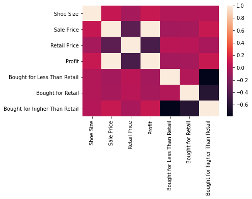

```python
# Genereal numeric correlations
# Analyze trend between shoe size and sale price
# Analyze trend between sale price and retail price
correlations = df.corr()
sns.heatmap(correlations)
```

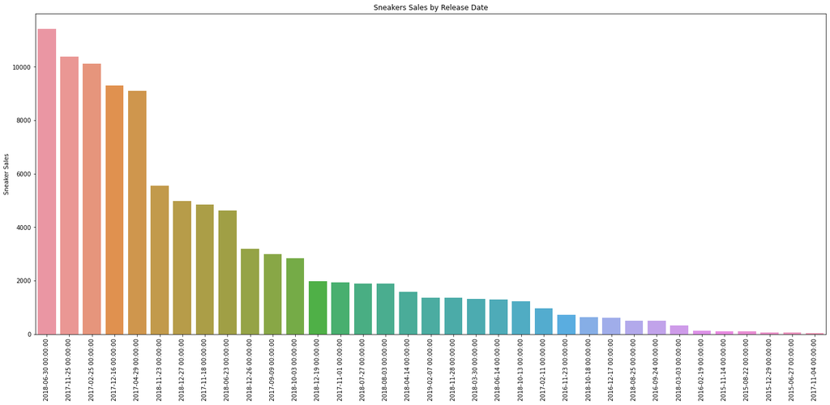

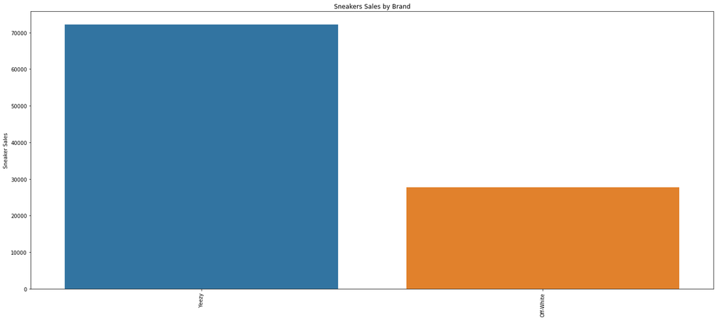

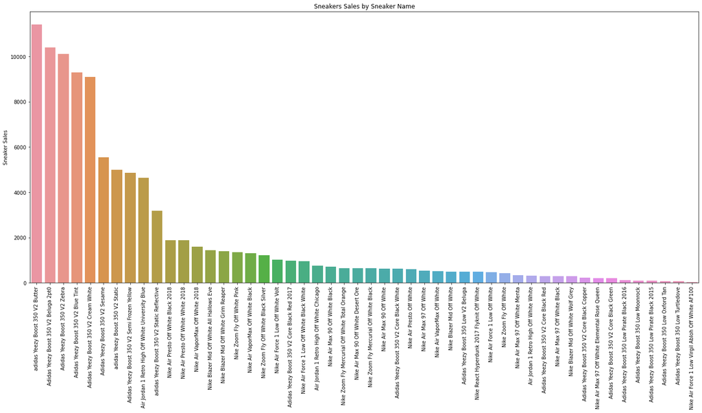

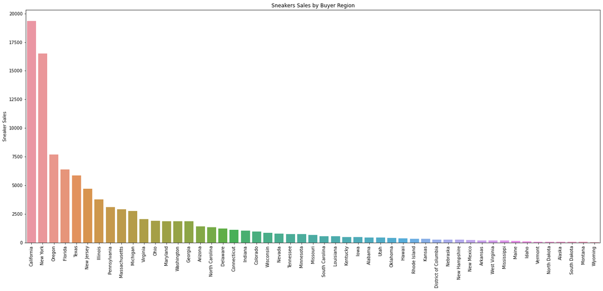

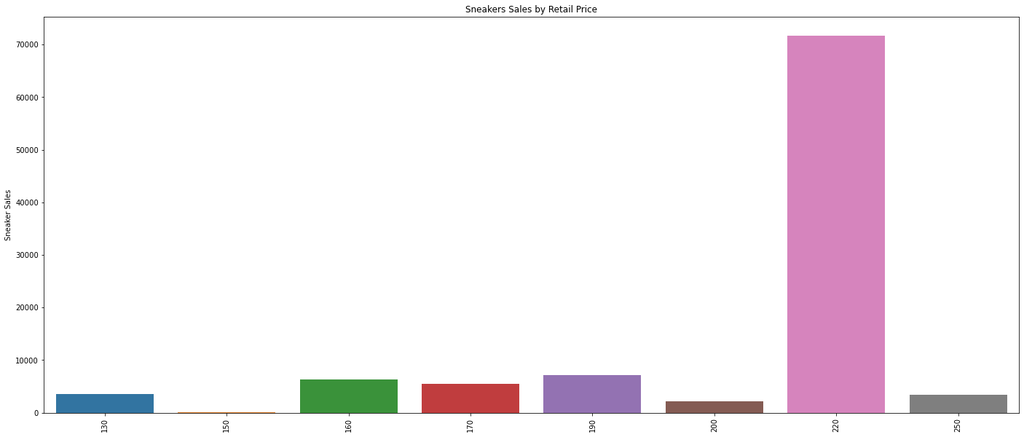

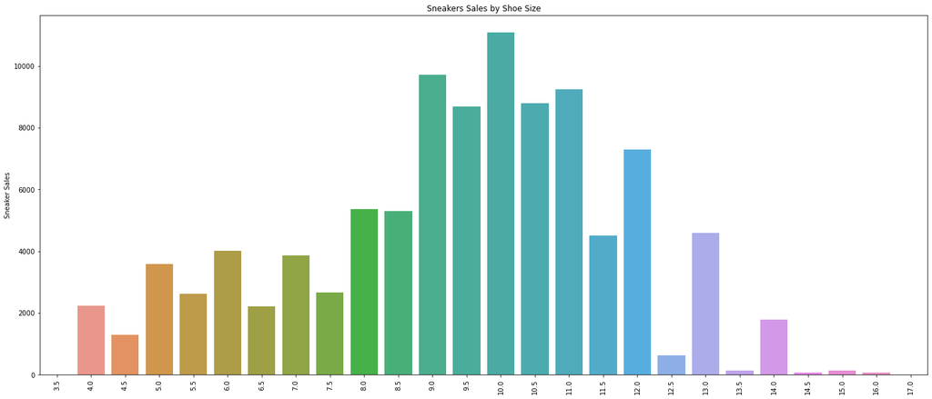

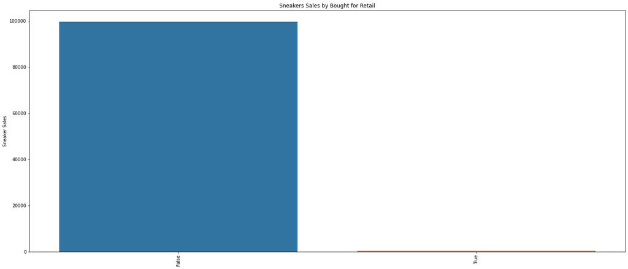

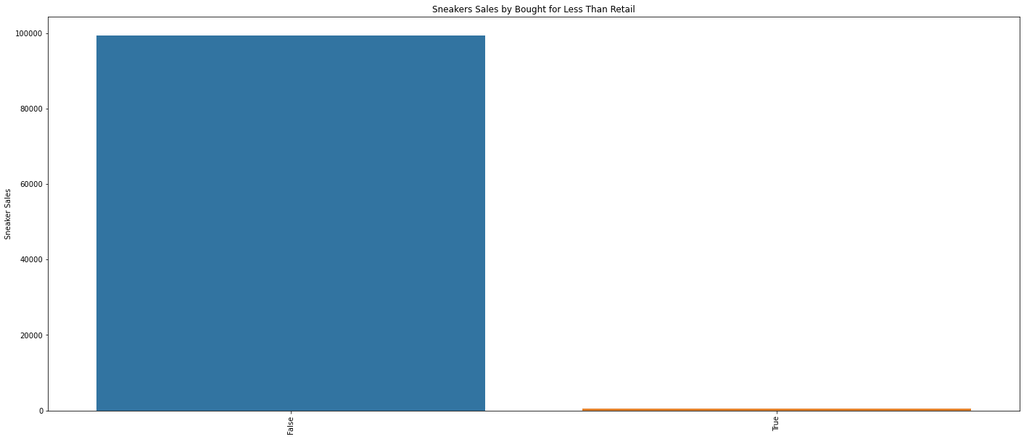

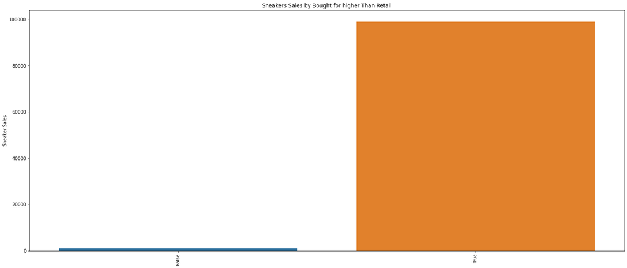

```python
# Release Date, Brand distribution, Sneaker Name, Buyer Region, Retail Price, Shoe Size analysis and plot
df_cat = ['Release Date', 'Brand','Sneaker Name','Buyer Region','Retail Price','Shoe Size', 'Bought for Retail', 'Bought for Less Than Retail','Bought for higher Than Retail']
for cat in df_cat:
    cat_num = df[str(cat)].value_counts()
    plt.figure(figsize=(24,10))
    chart = sns.barplot(x = cat_num.index, y= cat_num)
    chart.set_title("Sneakers Sales by %s" % (cat))
    plt.ylabel("Sneaker Sales")
    chart.set_xticklabels(chart.get_xticklabels(), rotation = 90)
    plt.gca().xaxis.set_major_locator(plt.MultipleLocator(1))
    plt.show(30)
```

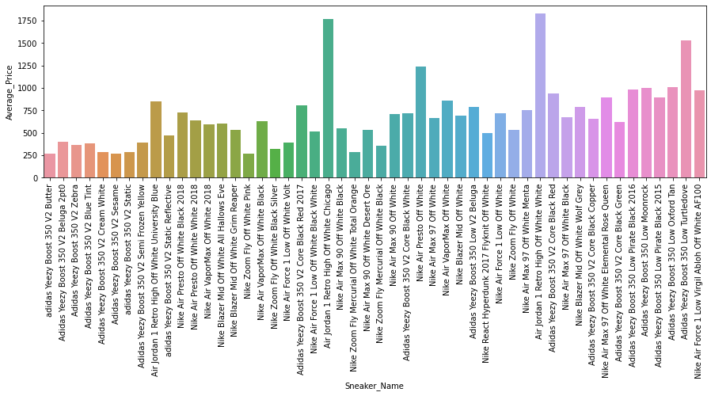

```python
# Analyze trend between Sneaker Name & Sale price
# Create average retail price df
bruh = df[['Sneaker Name', 'Sale Price']]

# Clean up this list
sneakernames = ['adidas Yeezy Boost 350 V2 Butter',
       'Adidas Yeezy Boost 350 V2 Beluga 2pt0',
       'Adidas Yeezy Boost 350 V2 Zebra',
       'Adidas Yeezy Boost 350 V2 Blue Tint',
       'Adidas Yeezy Boost 350 V2 Cream White',
       'Adidas Yeezy Boost 350 V2 Sesame', 'adidas Yeezy Boost 350 V2 Static',
       'Adidas Yeezy Boost 350 V2 Semi Frozen Yellow',
       'Air Jordan 1 Retro High Off White University Blue',
       'adidas Yeezy Boost 350 V2 Static Reflective',
       'Nike Air Presto Off White Black 2018',
       'Nike Air Presto Off White White 2018',
       'Nike Air VaporMax Off White 2018',
       'Nike Blazer Mid Off White All Hallows Eve',
       'Nike Blazer Mid Off White Grim Reaper', 'Nike Zoom Fly Off White Pink',
       'Nike Air VaporMax Off White Black',
       'Nike Zoom Fly Off White Black Silver',
       'Nike Air Force 1 Low Off White Volt',
       'Adidas Yeezy Boost 350 V2 Core Black Red 2017',
       'Nike Air Force 1 Low Off White Black White',
       'Air Jordan 1 Retro High Off White Chicago',
       'Nike Air Max 90 Off White Black',
       'Nike Zoom Fly Mercurial Off White Total Orange',
       'Nike Air Max 90 Off White Desert Ore',
       'Nike Zoom Fly Mercurial Off White Black', 'Nike Air Max 90 Off White',
       'Adidas Yeezy Boost 350 V2 Core Black White',
       'Nike Air Presto Off White', 'Nike Air Max 97 Off White',
       'Nike Air VaporMax Off White', 'Nike Blazer Mid Off White',
       'Adidas Yeezy Boost 350 Low V2 Beluga',
       'Nike React Hyperdunk 2017 Flyknit Off White',
       'Nike Air Force 1 Low Off White', 'Nike Zoom Fly Off White',
       'Nike Air Max 97 Off White Menta',
       'Air Jordan 1 Retro High Off White White',
       'Adidas Yeezy Boost 350 V2 Core Black Red',
       'Nike Air Max 97 Off White Black',
       'Nike Blazer Mid Off White Wolf Grey',
       'Adidas Yeezy Boost 350 V2 Core Black Copper',
       'Nike Air Max 97 Off White Elemental Rose Queen',
       'Adidas Yeezy Boost 350 V2 Core Black Green',
       'Adidas Yeezy Boost 350 Low Pirate Black 2016',
       'Adidas Yeezy Boost 350 Low Moonrock',
       'Adidas Yeezy Boost 350 Low Pirate Black 2015',
       'Adidas Yeezy Boost 350 Low Oxford Tan',
       'Adidas Yeezy Boost 350 Low Turtledove',
       'Nike Air Force 1 Low Virgil Abloh Off White AF100'
       ]
avgs = []
for name in sneakernames:
    shoerow = bruh.loc[bruh['Sneaker Name'] == name]
    avgs.append(shoerow.mean()[0])
AvgPrice = pd.Series(avgs)
SneakerName = pd.Series(sneakernames)
avgprice_df = pd.DataFrame(columns = ['Sneaker_Name', 'Average_Price'])
avgprice_df['Sneaker_Name'] = SneakerName
avgprice_df['Average_Price'] = AvgPrice

# Crerating visual of average shoe price
fig_dims = (15, 4)
fig, ax = plt.subplots(figsize=fig_dims)
chart = sns.barplot(x = avgprice_df['Sneaker_Name'] , y= avgprice_df['Average_Price'])
chart.set_xticklabels(chart.get_xticklabels(), rotation = 90)
plt.gca().xaxis.set_major_locator(plt.MultipleLocator(1))
```

```python
# Find average sale price by brand
avgs_2 = []
bds = df[['Brand', 'Sale Price']]
brands = [' Yeezy', 'Off-White']
for brand in brands:
    brandrow = bds.loc[bds['Brand'] == str(brand)]
    avgs_2.append(brandrow['Sale Price'].mean())
print('Yeezy average price: $' + str(avgs_2[0]))
print('Off-White average price: $' + str(avgs_2[1]))
```

```
Yeezy average price: $360.03255175854326
Off-White average price: $671.4812909260992
```

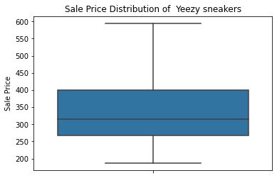

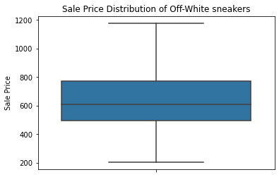

```python
# Create boxplot distribution of sales price by brand
for brand in brands:
    brandrow = bds.loc[bds['Brand'] == str(brand)]
    chart = sns.boxplot(y=brandrow["Sale Price"], showfliers = False)
    chart.set_title("Sale Price Distribution of %s sneakers" % (brand))
    plt.show()
```

```python
# Analyze trend between Sales Price and Order Date
# Find average sale price per day
dts = df[['Order Date', 'Sale Price']]
uniq_ord_dates = df['Order Date'].value_counts().index.tolist()
avg_3 = []

for date in uniq_ord_dates:
    daterow = dts.loc[dts['Order Date'] == str(date)]
    avg_3.append(daterow['Sale Price'].mean())

unq_dates = pd.Series(uniq_ord_dates)
date_avgs = pd.Series(avg_3)
dateprice_df = pd.DataFrame(columns = ['Order_date', 'Average_Price'])
dateprice_df['Order_date'] = unq_dates.sort_values(ascending = True)
dateprice_df['Average_Price'] = date_avgs
dateprice_df.head()
```

|  | Order_date | Average_Price |
| --- | --- | --- |
| 482 | 2017-09-01 | 653.000000 |
| 514 | 2017-09-02 | 649.600000 |
| 505 | 2017-09-03 | 672.437500 |
| 501 | 2017-09-04 | 623.764706 |
| 486 | 2017-09-05 | 648.772727 |

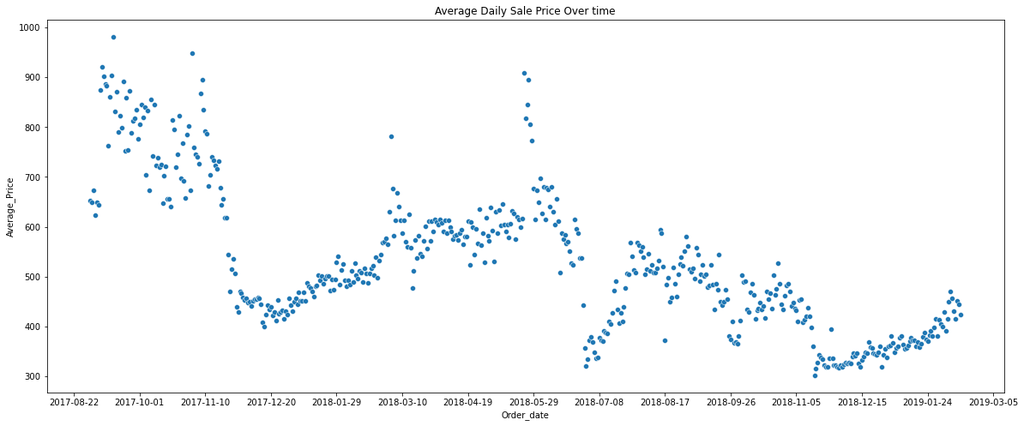

```python
# Create visualization of Average Sale Price Over time
fig_dims = (20, 8)
fig, ax = plt.subplots(figsize=fig_dims)
chart = sns.scatterplot(x="Order_date", y="Average_Price", data=dateprice_df)
plt.gca().xaxis.set_major_locator(plt.MultipleLocator(40))
chart.set_title("Average Daily Sale Price Over time")
```

```python
# Finding Average Sale Price on Release Dates Over Time
dts = df[['Release Date', 'Sale Price']]
uniq_rel_dates = df['Release Date'].value_counts().index.tolist()
avg_4 = []

for date in uniq_rel_dates:
    daterow = dts.loc[dts['Release Date'] == str(date)]
    avg_4.append(daterow['Sale Price'].mean())

unq_dates = pd.Series(uniq_rel_dates)
date_avgs = pd.Series(avg_4)
dateprice_df_2 = pd.DataFrame(columns = ['Release_date', 'Average_Price'])
dateprice_df_2['Release_date'] = unq_dates.sort_values(ascending = True)
dateprice_df_2['Average_Price'] = date_avgs
dateprice_df_2.head()
```

|  | Release_date | Average_Price |
| --- | --- | --- |
| 33 | 2015-06-27 | 1531.661765 |
| 31 | 2015-08-22 | 895.094737 |
| 30 | 2015-11-14 | 996.710000 |
| 32 | 2015-12-29 | 1011.514286 |
| 29 | 2016-02-19 | 984.237705 |

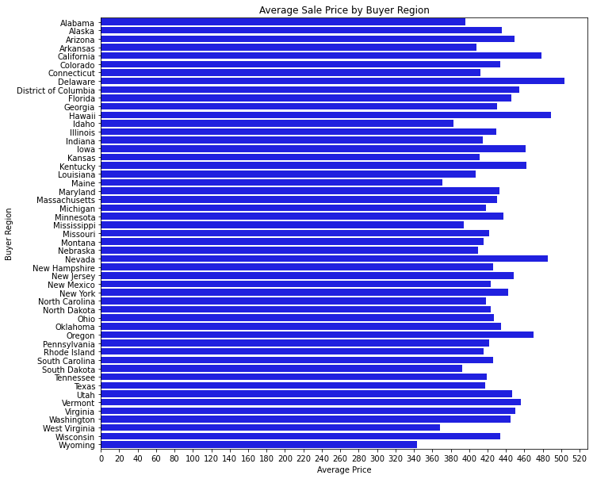

```python
# Analyze trend between buyer region and sale price

brg = df[['Buyer Region', 'Sale Price']]
unq_brgs = df['Buyer Region'].value_counts().index.tolist()
avg_5 = []

for region in unq_brgs:
    regionrow = brg.loc[brg['Buyer Region'] == str(region)]
    avg_5.append(regionrow['Sale Price'].mean())

unq_regions = pd.Series(unq_brgs)
region_avgs = pd.Series(avg_5)
regionprice_df = pd.DataFrame(columns = ['Buyer Region', 'Average Price'])
regionprice_df['Buyer Region'] = unq_regions.sort_values(ascending = True)
regionprice_df['Average Price'] = region_avgs

fig_dims = (11, 10)
fig, ax = plt.subplots(figsize=fig_dims)
chart = sns.barplot(x="Average Price", y="Buyer Region", data=regionprice_df, color="b")
plt.gca().xaxis.set_major_locator(plt.MultipleLocator(20))
chart.set_title("Average Sale Price by Buyer Region")
```

```python
# drop the columns of Shoe size for plot
new_df.drop('Shoe Size', axis = 1, inplace = True)
new_df.head()
```

|  | Order Date | Release Date | Brand | Sneaker Name | Sale Price | Retail Price | Profit | Buyer Region |
| --- | --- | --- | --- | --- | --- | --- | --- | --- |
| 0 | 2017-09-01 | 2016-09-24 | Yeezy | Adidas Yeezy Boost 350 Low V2 Beluga | 1097 | 220 | 877 | California |
| 1 | 2017-09-01 | 2016-11-23 | Yeezy | Adidas Yeezy Boost 350 V2 Core Black Copper | 685 | 220 | 465 | California |
| 2 | 2017-09-01 | 2016-11-23 | Yeezy | Adidas Yeezy Boost 350 V2 Core Black Green | 690 | 220 | 470 | California |
| 3 | 2017-09-01 | 2016-11-23 | Yeezy | Adidas Yeezy Boost 350 V2 Core Black Red | 1075 | 220 | 855 | Kentucky |
| 4 | 2017-09-01 | 2017-02-11 | Yeezy | Adidas Yeezy Boost 350 V2 Core Black Red 2017 | 828 | 220 | 608 | Rhode Island |

```python
# get the sum of each day about Sale price , Retail Price and Profit
sp = new_df.groupby('Order Date').sum()
```

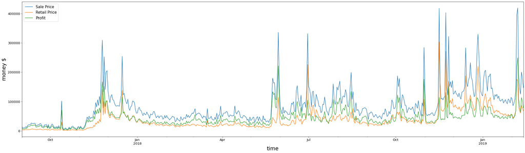

```python
# show the change about sum of Sale price, retail price and profit during time period
ax = sp.plot(figsize=(36,10), fontsize=13)
plt.legend(loc='best', fontsize=15)
ax.set_xlabel('time', fontsize=21)
ax.set_ylabel('money $', fontsize=21)
plt.show()
```

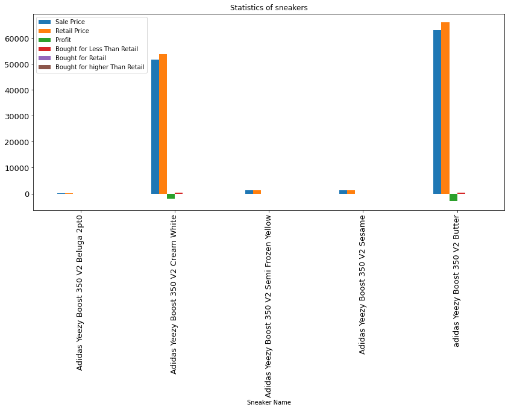

```python
# find the one which sale price lower than retail price
p_df.drop('Shoe Size', axis = 1, inplace = True)
p_df_loss = p_df.loc[df['Bought for Less Than Retail'] == True]
loss = p_df_loss.groupby('Sneaker Name').sum()
loss.plot(kind='bar', figsize=(14,6), fontsize=13, title='Statistics of sneakers')
plt.show()
```

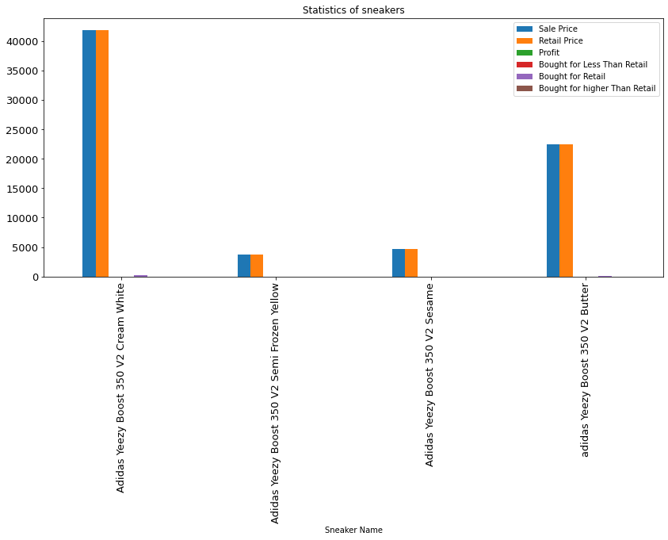

```python
p_df_equal = p_df.loc[df['Bought for Retail'] == True]
equal = p_df_equal.groupby('Sneaker Name').sum()
equal.plot(kind='bar', figsize=(14,6), fontsize=13, title='Statistics of sneakers')
plt.show()
```

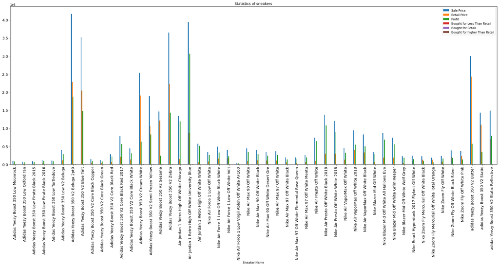

```python
p_df_gain = p_df.loc[df['Bought for higher Than Retail'] == True]
gain = p_df_gain.groupby('Sneaker Name').sum()
gain.plot(kind='bar', figsize=(30,10), fontsize=13, title='Statistics of sneakers')
plt.show()
```

## 4. Conclusion

### Now we know a little about the price fluctuation about several sneakers, which will help you to buy your favorite sneakers in suitable price or sell your sneakers to get more profit.

### This project is only small part of sales of sneakers from the Stockx, there will be too many sneakers transaction in future, hopefully every body can get their favorite sneakers with suitable price.

### if you want to see more, please follow the pages in Github.

## 5. Learning Process

### For this project , I have apply some techniques which I learnd in the data mining class, from the pre processing data and analyzing the data to get relationship among order date, sale price and retail price. These data are so clearly and correctly show us the fluctuation of the sneakers market. Hopefully this project can help you to get some useful information about the sneakers.

```python
jupyter nbconvert my_notebook.ipynb --to html --output output.html
```

[output not shown]